# CyclisticBikeShare_Project_02

Le Thi Thanh Tam

3/12/2022

## Scenario

Cyclistic - a bike-share company in Chicago. The director of marketing believes the company’s future success depends on maximizing the number of annual memberships. Therefore, Data analyst team wants to understand how casual riders and annual members use Cyclistic bikes differently. From these insights, will design a new marketing strategy to convert casual riders into annual members.

# How do annual members and casual riders use Cyclistic bikes differently ?

```r
#get the default working directory of R
getwd()
#set the desired working directory of R
setwd('E:/ThanhTam_DA/Cyclistic_Data')
#remove all the objects
rm(list = ls())
#clear the console
cat("\014")
#clear the plots
dev.off()
```

```r
# Install required packages
# tidyverse for data import and wrangling
# libridate for date functions
# ggplot for visualization
library(tidyverse)  #helps wrangle data
library(lubridate)  #helps wrangle date attributes
library(ggplot2)  #helps visualize data
```

## Import the datasets

```r
## The Cyclistic’s historical trip data is collected by every months, we will work on dataset from 2021/04 to 2022/02
# Import data
tripdata042021 <- read.csv("202104-divvy-tripdata.csv")
tripdata052021 <- read.csv("202105-divvy-tripdata.csv")
tripdata062021 <- read.csv("202106-divvy-tripdata.csv")
tripdata072021 <- read.csv("202107-divvy-tripdata.csv")
tripdata082021 <- read.csv("202108-divvy-tripdata.csv")
tripdata092021 <- read.csv("202109-divvy-tripdata.csv")
tripdata102021 <- read.csv("202110-divvy-tripdata.csv")
tripdata112021 <- read.csv("202111-divvy-tripdata.csv")
tripdata122021 <- read.csv("202112-divvy-tripdata.csv")
tripdata012022 <- read.csv("202201-divvy-tripdata.csv")
tripdata022022 <- read.csv("202202-divvy-tripdata.csv")
```

### Check the structure of each dataset before joining

```r
# See the column names of each file to make sure they will be match perfectly before joining data
colnames(tripdata012022)
colnames(tripdata022022)
colnames(tripdata042021)
colnames(tripdata052021)
colnames(tripdata062021)
colnames(tripdata072021)
colnames(tripdata082021)
colnames(tripdata092021)
colnames(tripdata102021)
colnames(tripdata112021)
colnames(tripdata122021)
# Internal structurer
str(tripdata012022)
str(tripdata022022)
str(tripdata042021)
str(tripdata052021)
str(tripdata062021)
str(tripdata072021)
str(tripdata082021)
str(tripdata092021)
str(tripdata102021)
str(tripdata112021)
str(tripdata122021)
```

### Create a new dataset by combining all dataset

```r
#Combine all data into a single dataset
all_trips <- rbind(tripdata042021,tripdata052021,tripdata062021,tripdata072021,
                   tripdata082021,tripdata092021,tripdata102021,tripdata112021,
                   tripdata122021,tripdata012022,tripdata022022)
```

```r
# Inspect the new table
colnames(all_trips)
```

```
##  [1] "ride_id"            "rideable_type"      "started_at"
##  [4] "ended_at"           "start_station_name" "start_station_id"
##  [7] "end_station_name"   "end_station_id"     "start_lat"
## [10] "start_lng"          "end_lat"            "end_lng"
## [13] "member_casual"
```

```r
str(all_trips)
```

```
## 'data.frame':    5439490 obs. of  13 variables:
##  $ ride_id           : chr  "6C992BD37A98A63F" "1E0145613A209000" "E498E15508A80BAD" "1887262AD101C604" ...
##  $ rideable_type     : chr  "classic_bike" "docked_bike" "docked_bike" "classic_bike" ...
##  $ started_at        : chr  "2021-04-12 18:25:36" "2021-04-27 17:27:11" "2021-04-03 12:42:45" "2021-04-17 09:17:42" ...
##  $ ended_at          : chr  "2021-04-12 18:56:55" "2021-04-27 18:31:29" "2021-04-07 11:40:24" "2021-04-17 09:42:48" ...
##  $ start_station_name: chr  "State St & Pearson St" "Dorchester Ave & 49th St" "Loomis Blvd & 84th St" "Honore St & Division St" ...
##  $ start_station_id  : chr  "TA1307000061" "KA1503000069" "20121" "TA1305000034" ...
##  $ end_station_name  : chr  "Southport Ave & Waveland Ave" "Dorchester Ave & 49th St" "Loomis Blvd & 84th St" "Southport Ave & Waveland Ave" ...
##  $ end_station_id    : chr  "13235" "KA1503000069" "20121" "13235" ...
##  $ start_lat         : num  41.9 41.8 41.7 41.9 41.7 ...
##  $ start_lng         : num  -87.6 -87.6 -87.7 -87.7 -87.7 ...
##  $ end_lat           : num  41.9 41.8 41.7 41.9 41.7 ...
##  $ end_lng           : num  -87.7 -87.6 -87.7 -87.7 -87.7 ...
##  $ member_casual     : chr  "member" "casual" "casual" "member" ...
```

```r
dim(all_trips)
```

```
## [1] 5439490      13
```

```r
head(all_trips)
```

|  | ride_id | rideable_type | started_at | ended_at | start_station_name | start_station_id | end_station_name | end_station_id | start_lat | start_lng | end_lat | end_lng | member_casual |
| --- | --- | --- | --- | --- | --- | --- | --- | --- | --- | --- | --- | --- | --- |
| 1 | 6C992BD37A98A63F | classic_bike | 2021-04-12 18:25:36 | 2021-04-12 18:56:55 | State St & Pearson St | TA1307000061 | Southport Ave & Waveland Ave | 13235 | 41.89745 | -87.62872 | 41.94815 | -87.66394 | member |
| 2 | 1E0145613A209000 | docked_bike | 2021-04-27 17:27:11 | 2021-04-27 18:31:29 | Dorchester Ave & 49th St | KA1503000069 | Dorchester Ave & 49th St | KA1503000069 | 41.80577 | -87.59246 | 41.80577 | -87.59246 | casual |
| 3 | E498E15508A80BAD | docked_bike | 2021-04-03 12:42:45 | 2021-04-07 11:40:24 | Loomis Blvd & 84th St | 20121 | Loomis Blvd & 84th St | 20121 | 41.74149 | -87.65841 | 41.74149 | -87.65841 | casual |
| 4 | 1887262AD101C604 | classic_bike | 2021-04-17 09:17:42 | 2021-04-17 09:42:48 | Honore St & Division St | TA1305000034 | Southport Ave & Waveland Ave | 13235 | 41.90312 | -87.67394 | 41.94815 | -87.66394 | member |
| 5 | C123548CAB2A32A5 | docked_bike | 2021-04-03 12:42:25 | 2021-04-03 14:13:42 | Loomis Blvd & 84th St | 20121 | Loomis Blvd & 84th St | 20121 | 41.74149 | -87.65841 | 41.74149 | -87.65841 | casual |
| 6 | 097E76F3651B1AC1 | classic_bike | 2021-04-25 18:43:18 | 2021-04-25 18:43:59 | Clinton St & Polk St | 15542 | Clinton St & Polk St | 15542 | 41.87147 | -87.64095 | 41.87147 | -87.64095 | casual |

```r
summary(all_trips)
```

```
##    ride_id          rideable_type       started_at          ended_at
##  Length:5439490     Length:5439490     Length:5439490     Length:5439490
##  Class :character   Class :character   Class :character   Class :character
##  Mode  :character   Mode  :character   Mode  :character   Mode  :character
##
##
##
##
##  start_station_name start_station_id   end_station_name   end_station_id
##  Length:5439490     Length:5439490     Length:5439490     Length:5439490
##  Class :character   Class :character   Class :character   Class :character
##  Mode  :character   Mode  :character   Mode  :character   Mode  :character
##
##
##
##
##    start_lat       start_lng         end_lat         end_lng
##  Min.   :41.64   Min.   :-87.84   Min.   :41.39   Min.   :-88.97
##  1st Qu.:41.88   1st Qu.:-87.66   1st Qu.:41.88   1st Qu.:-87.66
##  Median :41.90   Median :-87.64   Median :41.90   Median :-87.64
##  Mean   :41.90   Mean   :-87.65   Mean   :41.90   Mean   :-87.65
##  3rd Qu.:41.93   3rd Qu.:-87.63   3rd Qu.:41.93   3rd Qu.:-87.63
##  Max.   :45.64   Max.   :-73.80   Max.   :42.17   Max.   :-87.49
##                                   NA's   :4450    NA's   :4450
##  member_casual
##  Length:5439490
##  Class :character
##  Mode  :character
##
##
##
##
```

## Clean and Transform the data

```r
#We will work on the member_casual column. Let's take a look at the consistency of values in this
unique(all_trips$member_casual)
```

```
## [1] "member" "casual"
```

```r
# Format check
head(all_trips[,c("started_at", "ended_at")])
## Convert to date type
## Add column date, month, year and weekday to dataset for further analyze
all_trips$date <- as.Date(all_trips$started_at)
all_trips$day_of_week <- format(as.Date(all_trips$date), "%A")
all_trips$day <- format(as.Date(all_trips$date), "%d")
all_trips$month <- format(as.Date(all_trips$date), "%m")
all_trips$year <- format(as.Date(all_trips$date), "%Y")
```

```r
head(all_trips)
```

|  | ride_id | rideable_type | started_at | ended_at | start_station_name | start_station_id | end_station_name | end_station_id | start_lat | start_lng | end_lat | end_lng | member_casual | date | day_of_week | day | month | year |
| --- | --- | --- | --- | --- | --- | --- | --- | --- | --- | --- | --- | --- | --- | --- | --- | --- | --- | --- |
| 1 | 6C992BD37A98A63F | classic_bike | 2021-04-12 18:25:36 | 2021-04-12 18:56:55 | State St & Pearson St | TA1307000061 | Southport Ave & Waveland Ave | 13235 | 41.89745 | -87.62872 | 41.94815 | -87.66394 | member | 2021-04-12 | Monday | 12 | 04 | 2021 |
| 2 | 1E0145613A209000 | docked_bike | 2021-04-27 17:27:11 | 2021-04-27 18:31:29 | Dorchester Ave & 49th St | KA1503000069 | Dorchester Ave & 49th St | KA1503000069 | 41.80577 | -87.59246 | 41.80577 | -87.59246 | casual | 2021-04-27 | Tuesday | 27 | 04 | 2021 |
| 3 | E498E15508A80BAD | docked_bike | 2021-04-03 12:42:45 | 2021-04-07 11:40:24 | Loomis Blvd & 84th St | 20121 | Loomis Blvd & 84th St | 20121 | 41.74149 | -87.65841 | 41.74149 | -87.65841 | casual | 2021-04-03 | Saturday | 03 | 04 | 2021 |
| 4 | 1887262AD101C604 | classic_bike | 2021-04-17 09:17:42 | 2021-04-17 09:42:48 | Honore St & Division St | TA1305000034 | Southport Ave & Waveland Ave | 13235 | 41.90312 | -87.67394 | 41.94815 | -87.66394 | member | 2021-04-17 | Saturday | 17 | 04 | 2021 |
| 5 | C123548CAB2A32A5 | docked_bike | 2021-04-03 12:42:25 | 2021-04-03 14:13:42 | Loomis Blvd & 84th St | 20121 | Loomis Blvd & 84th St | 20121 | 41.74149 | -87.65841 | 41.74149 | -87.65841 | casual | 2021-04-03 | Saturday | 03 | 04 | 2021 |
| 6 | 097E76F3651B1AC1 | classic_bike | 2021-04-25 18:43:18 | 2021-04-25 18:43:59 | Clinton St & Polk St | 15542 | Clinton St & Polk St | 15542 | 41.87147 | -87.64095 | 41.87147 | -87.64095 | casual | 2021-04-25 | Sunday | 25 | 04 | 2021 |

```r
# Add a new column "ride_length" to calculate in second
all_trips$ride_length <- difftime(all_trips$ended_at, all_trips$started_at)
```

```r
# Inspect the structure of dataset
str(all_trips)
is.factor(all_trips$ride_length) # False
is.numeric(all_trips$ride_length) # Fasle
```

```r
# Convert "ride_length" to numeric so we can run calculations
all_trips$ride_length <- as.numeric(as.character(all_trips$ride_length))
is.numeric(all_trips$ride_length) # True
min(all_trips$ride_length) # -3482
# There has negative datas in ride_length
# Create a new data with deleted negatives values in ride_length
all_trips_v2 <- all_trips[!(all_trips$ride_length < 0),]
#min(all_trips_v2$ride_length)
```

## Descriptive Analysis

- The number of each ride type user

```r
table(all_trips_v2$member_casual)
```

```
##
##  casual  member
## 2456602 2982745
```

In total of 5,439,347 users id, there has 2,456,602 casual users and 2,982,745 member users

- Ride length data

```r
summary(all_trips_v2$ride_length)
```

```
##    Min. 1st Qu.  Median    Mean 3rd Qu.    Max.
##       0     399     711    1302    1291 3356649
```

As we can see above the description of ride length data 75% riders ride for 1291 seconds but the maximum ride length is 3356649 seconds.

### Compare members and casual users according to ride length

```r
aggregate(all_trips_v2$ride_length ~ all_trips_v2$member_casual, FUN = mean)
```

| all_trips_v2$member_casual | all_trips_v2$ride_length |
| --- | --- |
| casual | 1902.4894 |
| member | 807.6996 |

```r
aggregate(all_trips_v2$ride_length ~ all_trips_v2$member_casual, FUN = median)
```

| all_trips_v2$member_casual | all_trips_v2$ride_length |
| --- | --- |
| casual | 949 |
| member | 568 |

```r
aggregate(all_trips_v2$ride_length ~ all_trips_v2$member_casual, FUN = max)
```

| all_trips_v2$member_casual | all_trips_v2$ride_length |
| --- | --- |
| casual | 3356649 |
| member | 89998 |

```r
aggregate(all_trips_v2$ride_length ~ all_trips_v2$member_casual, FUN = min)
```

| all_trips_v2$member_casual | all_trips_v2$ride_length |
| --- | --- |
| casual | 0 |
| member | 0 |

The average in ride length of casual riders is 1902s higher than member riders (807.7s) The median ride length of casual riders is 949s, and member riders is 568s The maximum ride time of casual riders (3356649s) is much higher than member riders (89998s)

### Next see the average ride time by each WEEKDAY for members and casual users

```r
aggregate(all_trips_v2$ride_length ~ all_trips_v2$member_casual + all_trips_v2$day_of_week, FUN = mean)
```

| all_trips_v2$member_casual | all_trips_v2$day_of_week | all_trips_v2$ride_length |
| --- | --- | --- |
| casual | Friday | 1811.5677 |
| member | Friday | 794.2411 |
| casual | Monday | 1876.7510 |
| member | Monday | 779.6102 |
| casual | Saturday | 2053.5308 |
| member | Saturday | 903.3627 |
| casual | Sunday | 2241.4577 |
| member | Sunday | 927.3992 |
| casual | Thursday | 1667.7428 |
| member | Thursday | 761.7711 |

[output cut: 4 more lines]

```r
# The day of week are out of order
all_trips_v2$day_of_week <- ordered(all_trips_v2$day_of_week, levels = c("Sunday","Monday", "Tuesday","Wednesday", "Thursday", "Friday", "Saturday"))
# Now run again
memory.size()
memory.limit()
memory.limit(size=56000)
```

```r
aggregate(all_trips_v2$ride_length ~ all_trips_v2$member_casual + all_trips_v2$day_of_week, FUN = mean)
```

| all_trips_v2$member_casual | all_trips_v2$day_of_week | all_trips_v2$ride_length |
| --- | --- | --- |
| casual | Sunday | 2241.4577 |
| member | Sunday | 927.3992 |
| casual | Monday | 1876.7510 |
| member | Monday | 779.6102 |
| casual | Tuesday | 1651.6258 |
| member | Tuesday | 758.2647 |
| casual | Wednesday | 1658.5519 |
| member | Wednesday | 758.2755 |
| casual | Thursday | 1667.7428 |
| member | Thursday | 761.7711 |

[output cut: 4 more lines]

### Analyze ridership data by type and weekday

```r
# See the number of rides and average duration by type during weekday
all_trips_v2 %>%
  mutate(weekday = wday(started_at, label = TRUE)) %>%
  group_by(member_casual, weekday) %>%
  summarise(number_of_riders = n(), average_duration = mean(ride_length)) %>%
  arrange(member_casual, weekday)
```

| member_casual | weekday | number_of_riders | average_duration |
| --- | --- | --- | --- |
| casual | Sun | 466226 | 2241.4577 |
| casual | Mon | 278544 | 1876.7510 |
| casual | Tue | 266217 | 1651.6258 |
| casual | Wed | 271860 | 1658.5519 |
| casual | Thu | 281608 | 1667.7428 |
| casual | Fri | 357121 | 1811.5677 |
| casual | Sat | 535026 | 2053.5308 |
| member | Sun | 365649 | 927.3992 |
| member | Mon | 409979 | 779.6102 |
| member | Tue | 455689 | 758.2647 |

[output cut: 4 more lines]

### Create Visualization for number of riders by type

- Number of riders on weekday

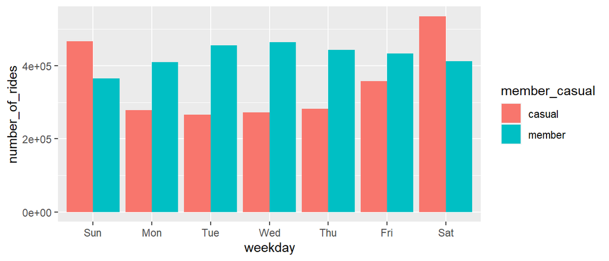

```r
# Create a graph to visualize the number of riders by ride type during weekday
all_trips_v2 %>%
  mutate(weekday = wday(started_at, label = TRUE)) %>%
  group_by(member_casual, weekday) %>%
  summarize(number_of_rides = n(), average_duration = mean(ride_length)) %>%
  arrange(member_casual,weekday) %>%
  ggplot(aes(x = weekday, y = number_of_rides, fill = member_casual)) + geom_col(position = "dodge")
```

From the chart above we can see the clearly difference only for casual users ride highly on Saturday and then Sunday Whereas member of users use bike at the almost constant rate during the week.

- Number of riders per day

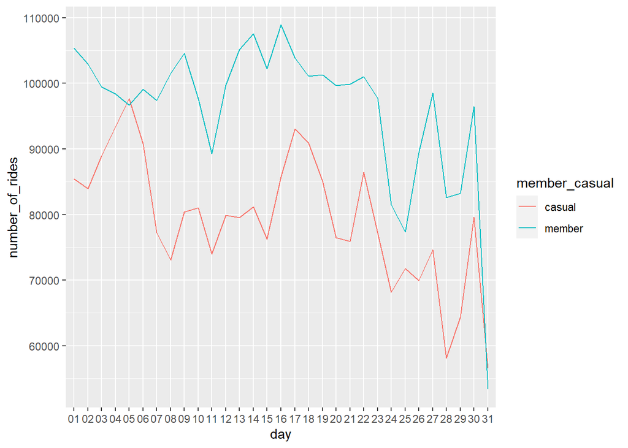

```r
all_trips_v2 %>%
  group_by(member_casual, day) %>%
  summarize(number_of_rides = n(), average_duration = mean(ride_length)) %>%
  arrange(member_casual,day) %>%
  ggplot(aes(x = day, y = number_of_rides,group = member_casual, color = member_casual)) + geom_line()
```

We can certainly say members use bikes more often than casual in general.

- Number of riders per month

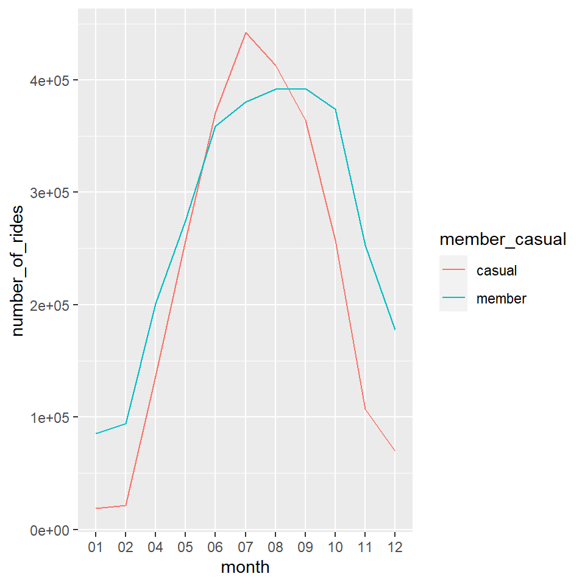

```r
all_trips_v2 %>%
  group_by(member_casual, month) %>%
  summarize(number_of_rides = n(), average_duration = mean(ride_length)) %>%
  arrange(member_casual,month) %>%
  ggplot(aes(x = month, y = number_of_rides,group = member_casual, color = member_casual)) + geom_line()
```

### Create Visualization for rider length

- Usage of ride type based on ride length per week

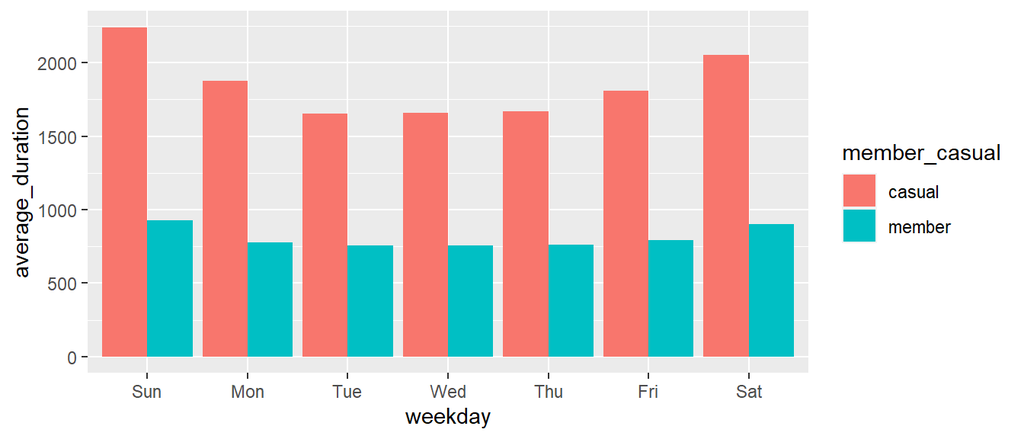

```r
# Create a graph to visualize the average duration by type during weekday
all_trips_v2 %>%
  mutate(weekday = wday(started_at, label = TRUE)) %>%
  group_by(member_casual, weekday) %>%
  summarize(number_of_rides = n(), average_duration = mean(ride_length)) %>%
  arrange(member_casual,weekday) %>%
  ggplot(aes(x = weekday, y = average_duration, fill = member_casual)) + geom_col(position = "dodge")
```

The above graph shows the clearly understanding about the average ride length. Casual type users ride much longer and as expected weekend got the higher ride length than others.

- Usage of ride type based on ride length per day

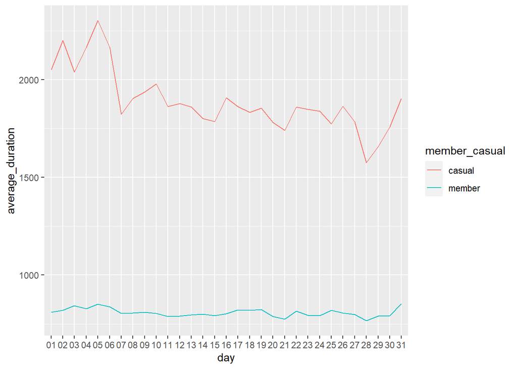

```r
all_trips_v2 %>%
  group_by(member_casual, day) %>%
  summarize(number_of_rides = n(), average_duration = mean(ride_length)) %>%
  arrange(member_casual,day) %>%
  ggplot(aes(x = day, y = average_duration,group = member_casual, color = member_casual)) + geom_line()
```

The graph above shows the big gap between casual and member type. casual users spent much more time per day in using bikes more than members.

- Usage of ride type based on ride length per month

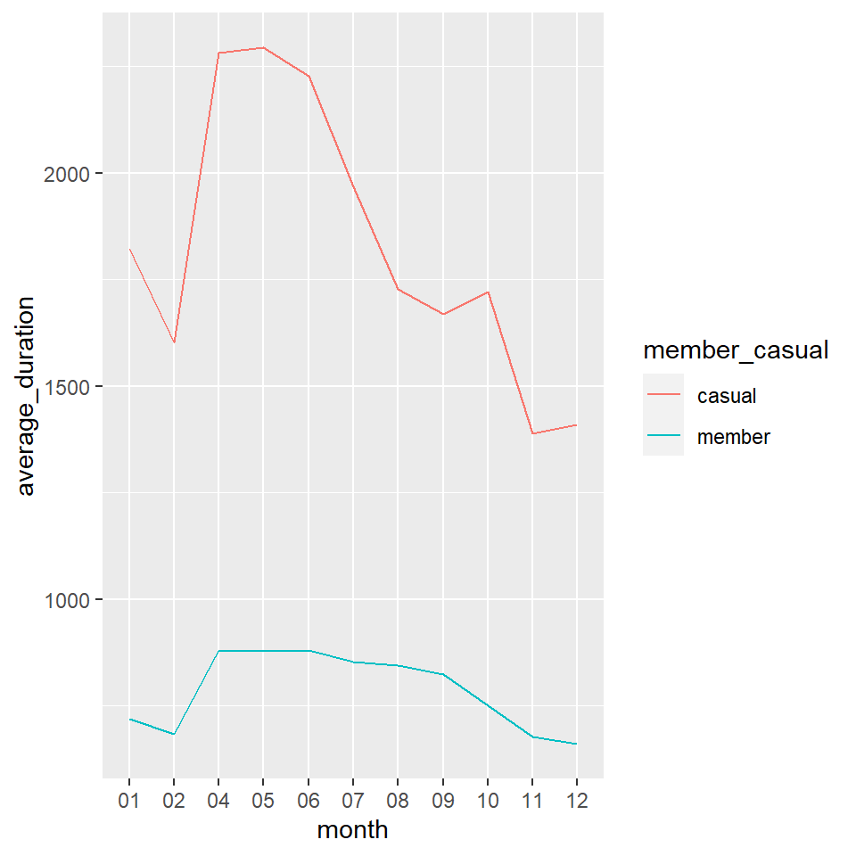

```r
all_trips_v2 %>%
  group_by(member_casual, month) %>%
  summarize(number_of_rides = n(), average_duration = mean(ride_length)) %>%
  arrange(member_casual,month) %>%
  ggplot(aes(x = month, y = average_duration,group = member_casual, color = member_casual)) + geom_line()
```

Also we can see the result from table above, casual users spend much more time than member users per month using bike.

# My recommendations

- From the above results, we can see casual riders ride the most during weekends and from June to August (could be Summer time, people tend to use bikes more often). So different price strategy should be considered. That would be equivalent to the savings for those who make a change to annual membership.
- Also we can see the ride length of casual riders is higher than annual members in general. So it should be increase cost ride time for casual type.
- Our purpose to maximize the number of annual memberships, therefore take care of existing annual members is also crucial. For example, can conduct discount offers for monthly payment to an annual riders who introducing their friends or for existing casual riders who register as a member.